# Collate_rfp_cds_counts[20230523]

Load all the required packages:

```r
library(riboWaltz)
library(tidyr)
library(dplyr)
library(stringr)
library(ggplot2)
```

This notebook processes .bam files generated using STAR alignment against primary human GRCh38 GENCODE annotation. .bam files used are in ./data/Try2 Trying with subsampled data i ./data/Try3

I am using riboWaltz to process this data. I create annotation_dt using the human primary assembly basic annotation that I used to align my RFP data with STAR. I’m also loading the data and convert them into list.

```r
bam_list <- bamtolist("data/Try3", annotation = annotation_dt, refseq_sep = "|")
```

```
Reading Nterm_RFP_1.bam
Input reads: 26.404 M
Good! Number of indel below indel_threshold for all reads. No reads removed.
Great! All reads' reference transcript IDs were found in the annotation table. No reads removed.
0.905 M  (3.429 %) reads removed: mapping on negative strand.
Output reads: 25.499 M
Done! Nterm_RFP_1.bam has been loaded as Nterm_RFP_1

Reading Nterm_RFP_2.bam
Input reads: 26.407 M
Good! Number of indel below indel_threshold for all reads. No reads removed.
Great! All reads' reference transcript IDs were found in the annotation table. No reads removed.
0.736 M  (2.785 %) reads removed: mapping on negative strand.
Output reads: 25.671 M
Done! Nterm_RFP_2.bam has been loaded as Nterm_RFP_2

Reading Nterm_RFP_3.bam
Input reads: 26.425 M
Good! Number of indel below indel_threshold for all reads. No reads removed.
Great! All reads' reference transcript IDs were found in the annotation table. No reads removed.
0.515 M  (1.949 %) reads removed: mapping on negative strand.
Output reads: 25.910 M
Done! Nterm_RFP_3.bam has been loaded as Nterm_RFP_3

Reading wt_RFP_1.bam
Input reads: 26.418 M
Good! Number of indel below indel_threshold for all reads. No reads removed.
Great! All reads' reference transcript IDs were found in the annotation table. No reads removed.
0.825 M  (3.122 %) reads removed: mapping on negative strand.
Output reads: 25.593 M
Done! wt_RFP_1.bam has been loaded as wt_RFP_1

Reading wt_RFP_2.bam
Input reads: 26.420 M
Good! Number of indel below indel_threshold for all reads. No reads removed.
Great! All reads' reference transcript IDs were found in the annotation table. No reads removed.
1.010 M  (3.821 %) reads removed: mapping on negative strand.
Output reads: 25.410 M
Done! wt_RFP_2.bam has been loaded as wt_RFP_2

Reading wt_RFP_3.bam
Input reads: 26.427 M
Good! Number of indel below indel_threshold for all reads. No reads removed.
Great! All reads' reference transcript IDs were found in the annotation table. No reads removed.
0.764 M  (2.889 %) reads removed: mapping on negative strand.
Output reads: 25.663 M
Done! wt_RFP_3.bam has been loaded as wt_RFP_3
```

I don’t filter the reads because doing so causes me to lose 99% of the reads.. The periodicity in this data is not good.

```r
# Try filter only read lengths that satisfy a periodicity threshold
# (i.e. 70% of the reads fall in one of the three reading frames along the CDS)
#filtered_bam_list <- length_filter(data = bam_list,
#                                   length_filter_mode = "periodicity",
#                                   periodicity_threshold = 70)
# This doesn't seem to work? It threw away 99.9% of the reads. The reads kept have much longer length.
# Apparently it is because I don't have good periodicity to begin with. RNAse or CHX might be an issue.
```

Call for psite, flanking = 6, extremity = “auto” Use default recommended settings: Also save the offsets per sample in a text file

```r
offsets <- psite(data = bam_list)
```

```
processing Nterm_RFP_1
best offset: 12 nts from the 5' end
processing Nterm_RFP_2
best offset: 12 nts from the 5' end
processing Nterm_RFP_3
best offset: 12 nts from the 5' end
processing wt_RFP_1
best offset: 11 nts from the 5' end
processing wt_RFP_2
best offset: 11 nts from the 5' end
processing wt_RFP_3
best offset: 12 nts from the 5' end
```

Get the main table of reads with psite information. Tried saving each psite list for each sample, but the filesize is way too big. Don’t do it.

```r
reads_psite_list <- psite_info(bam_list, offsets, site=c("psite", "asite", "esite"),
                               fastapath = "data/Try2/GRCh38.primary_assembly.genome.fa",
                               fasta_genome = TRUE, refseq_sep = " ",
                               gtfpath = "data/Try2/gencode.v43.primary_assembly.basic.annotation.gtf")
```

```
Import genomic features from the file as a GRanges object ... OK
Prepare the 'metadata' data frame ... OK
Make the TxDb object ... Warning: The "phase" metadata column contains non-NA values for features of type stop_codon. This information was
  ignored.OK
```

```
processing Nterm_RFP_1
1. adding p-site position
2. adding transcript region
3. adding nucleotide sequence(s)
```

```
Error in .Call2("C_solve_user_SEW", refwidths, start, end, width, translate.negative.coord,  :
  solving row 2066: 'allow.nonnarrowing' is FALSE and the supplied end (2026) is > refwidth
```

Check how the reads are distributed for a given transcript.

```r
library(tidyr)
library(dplyr)
library(stringr)
library(ggplot2)

# To plot read counts against position given a particular gene in a given sample:
transcript_id = "ENST00000398594.4"
reads_psite_sample = "Nterm_dep_rep3_RFP_Aligned.toTranscriptome.out"

# Get the read counts for a given p-siste position of a specific transcript in a given sample.
psite_counts <- reads_psite_list[[reads_psite_sample]][
  reads_psite_list[[reads_psite_sample]]$transcript == transcript_id ,
  ]$psite

# Convert counts table to data frame, change the column names.
counts <- as.data.frame(table(psite_counts))
colnames(counts) <- c("Position", "ReadCount")

# Generate a sequence of numbers from 0 or min. number to the max. number.
counts$Position <- as.numeric(as.character(counts$Position))
number_range <- seq(pmin(min(counts$Position), 0), max(counts$Position))

# Complete the data frame with missing numbers and set their counts to 0.
# Normalize ReadCount with the size of the library.
nrow_reads = nrow(reads_psite_list[[reads_psite_sample]])
counts_complete <- counts %>%
  complete(Position = number_range) %>%
  replace_na(list(ReadCount = 0)) %>%
  mutate(ReadCount = ReadCount / nrow_reads * 1000000)

# Parse information about genotype, rfp/rna, and rep number.
genotype <- ""
if (grepl("wt", reads_psite_sample)) genotype = "wt" else genotype = "Nterm"
rfp_or_rna  <- ""
if (grepl("rfp", reads_psite_sample)) rfp_or_rna = "RFP" else rfp_or_rna = "RNA"
rep_number <- ""
if (grepl("rep", reads_psite_sample)) {
  # Extract the number immediately following "rep"
  rep_number <- str_extract(reads_psite_sample, "(?<=rep)\\d+")
  }
# Combine the genotype, rfp/rna, and rep number information into a new sample name.
sample_name = paste(genotype, rfp_or_rna, rep_number, sep = "_")

p <- ggplot(counts_complete, aes(x = Position, y = ReadCount)) +
  geom_line() +
  labs(x = "position", y = "read count", title = paste(transcript_id, " read counts in ", sample_name), sep = "") +
  theme_bw() +
  theme(panel.grid.minor = element_blank()) +
  coord_cartesian(ylim = c(0,1)) +
  scale_x_continuous(n.breaks=20)

#Limit max position to 5000 for ZNF562
#Limit max position to 500 for LLPH
#Limit max position to 350 for SNURF
#Limit max position to 300 for SEM1

#ggsave(filename = paste("output/Try2/", transcript_id, "_", sample_name, ".png", sep =""), plot = p, width = 8, height = 4, dpi = 600)
```

Checking for codon usage

```r
wtNterm1_psite <- codon_usage_psite(reads_psite_list, annotation = annotation_dt, sample = wt1_Nterm1,
                                fastapath = fasta_path, gtfpath = gtf_path, fasta_genome = TRUE,
                                refseq_sep = " ", label_scatter = TRUE, label_number = 5,
                                site = "psite", label_aminoacid = TRUE)
```

```
Import genomic features from the file as a GRanges object ... OK
Prepare the 'metadata' data frame ... OK
Make the TxDb object ... OK
Warning: Vectorized input to `element_text()` is not officially supported.
ℹ Results may be unexpected or may change in future versions of ggplot2.Warning: Vectorized input to `element_text()` is not officially supported.
ℹ Results may be unexpected or may change in future versions of ggplot2.
```

```r
wtNterm2_psite <- codon_usage_psite(reads_psite_list, annotation = annotation_dt, sample = wt2_Nterm2,
                                fastapath = fasta_path, gtfpath = gtf_path, fasta_genome = TRUE,
                                refseq_sep = " ", label_scatter = TRUE, label_number = 5,
                                site = "psite", label_aminoacid = TRUE)
```

```
Import genomic features from the file as a GRanges object ... OK
Prepare the 'metadata' data frame ... OK
Make the TxDb object ... OK
Warning: Vectorized input to `element_text()` is not officially supported.
ℹ Results may be unexpected or may change in future versions of ggplot2.Warning: Vectorized input to `element_text()` is not officially supported.
ℹ Results may be unexpected or may change in future versions of ggplot2.
```

```r
wtNterm3_psite <- codon_usage_psite(reads_psite_list, annotation = annotation_dt, sample = wt3_Nterm3,
                                fastapath = fasta_path, gtfpath = gtf_path, fasta_genome = TRUE,
                                refseq_sep = " ", label_scatter = TRUE, label_number = 5,
                                site = "psite", label_aminoacid = TRUE)
```

```
Import genomic features from the file as a GRanges object ... OK
Prepare the 'metadata' data frame ... OK
Make the TxDb object ... OK
Warning: Vectorized input to `element_text()` is not officially supported.
ℹ Results may be unexpected or may change in future versions of ggplot2.Warning: Vectorized input to `element_text()` is not officially supported.
ℹ Results may be unexpected or may change in future versions of ggplot2.
```

Checking read length distribution. It seemed that for wild type average, I have longer read length overall compared to Nterm average. Nevertheless, the median for both is between 28-29.

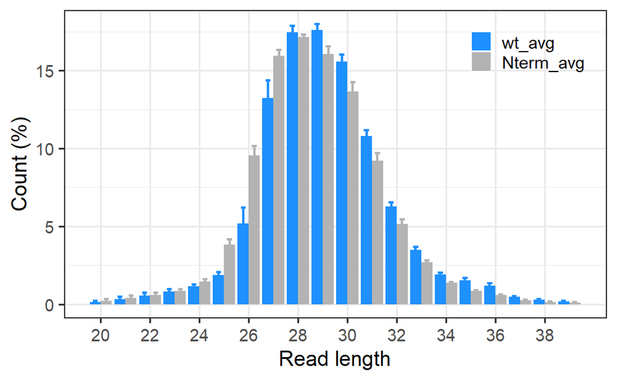

Checking for trinucleotide periodicity. Generally the P-site signal is a bit low..

[figure not shown]

```r
sample_list <- list("wt_avg" = c("wt_dep_rep1_RFP_Aligned.toTranscriptome.out", "wt_dep_rep2_RFP_Aligned.toTranscriptome.out", "wt_dep_rep3_RFP_Aligned.toTranscriptome.out"),
                    "Nterm_avg" = c("Nterm_dep_rep1_RFP_Aligned.toTranscriptome.out", "Nterm_dep_rep2_RFP_Aligned.toTranscriptome.out", "Nterm_dep_rep3_RFP_Aligned.toTranscriptome.out"))

example_metaprofile_overlaid <- metaprofile_psite(reads_psite_list, annotation_dt, sample = sample_list,
                                                  multisamples = "average", plot_style = "overlaid",
                                                  utr5l = 20, cdsl = 40, utr3l = 20,
                                                  frequency = TRUE, plot_title = "transcript",
                                                  colour = c("aquamarine4", "gray70"))
example_metaprofile_overlaid[["plot"]]
```

[output not shown]